# Índice de Desarrollo Humano

Autor/a

Halena Ruiz

# Introducción

Este documento presenta un análisis exploratorio del **Índice de Desarrollo Humano (IDH)** para los países de Argentina, Colombia, España y Venezuela, utilizando datos de *Our World in Data*.

# Descarga y Preparación de Datos

En esta sección, descargamos los datos del IDH, realizamos una limpieza y una modificación inicial.

**Código**

```r
# Extraemos los datos seleccionando los países de interés y limpiamos el nombre de las columnas
df_indice_desarrollo_humano <- owid_get('human-development-index', entities = c("ARG", "COL", "ESP", "VEN")) %>%
  select(-entity_id) %>%
  janitor::clean_names()

# Definimos la variable "promedio"
promedio_hdi <- mean(df_indice_desarrollo_humano$hdi_sex_total)

# Ahora modificamos la data frame agregándole una columna nueva con etiquetas de "alto_indice" y "bajo_indice", clasificado según su valor frente al "promedio"
df_indice_desarrollo_humano <- df_indice_desarrollo_humano %>%
  mutate(
    indice_hdi = ifelse(df_indice_desarrollo_humano$hdi_sex_total > promedio_hdi, "alto_indice", "bajo_indice")
  )
```

# Análisis Gráfico del IDH

A continuación, exploramos los datos a través de una serie de visualizaciones creadas con `ggplot2`.

## 1. Número de Observaciones por País

Este gráfico de barras muestra el número total de observaciones (registros de años) disponibles para cada país en el dataset.

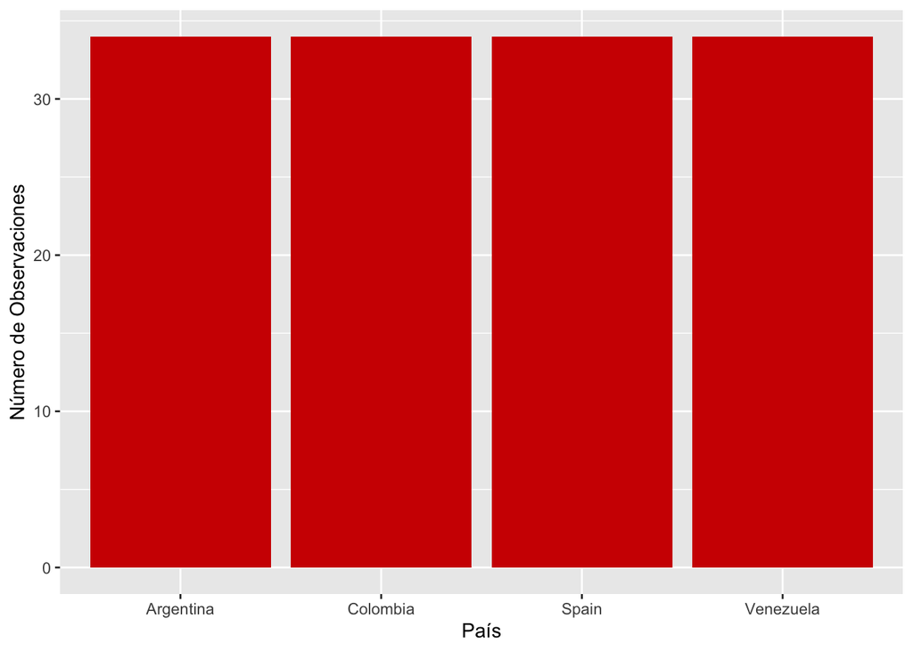

Como observamos en este gráfico, los cuatro países poseen el mismo número de observaciones (34).

## 2. Boxplots del IDH por País

Los boxplots nos permiten visualizar la distribución y dispersión del IDH para cada país, mostrando la mediana, los cuartiles y posibles valores atípicos.

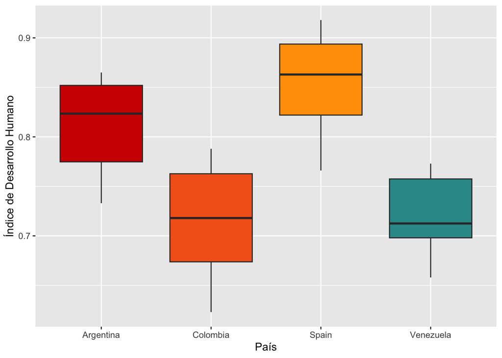

Cada caja representa el rango intercuartil, la línea central es la mediana, y los “bigotes” (líneas que se extienden desde la caja) indican la variabilidad de los datos.

## 3. Histograma General del IDH

Este histograma muestra la distribución general de la frecuencia absoluta del IDH en todo el dataset.

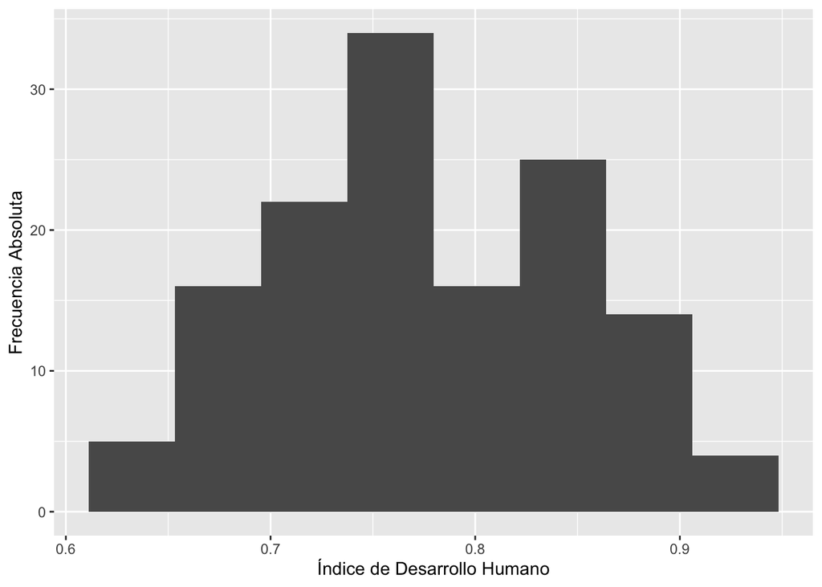

La mayor concentración de datos (la barra más alta) se encuentra en el rango del IDH entre aproximadamente 0.75 y 0.80. Esto sugiere que la mayoría de los valores de IDH en esta muestra caen dentro de este rango. Hay una cantidad considerable de datos en el rango de 0.70 a 0.75, también en el rango de 0.80 a 0.85, y un poco menos en el rango de 0.85 a 0.90. Hay menos datos en los extremos, es decir, en los rangos más bajos (alrededor de 0.60-0.65 y 0.65-0.70) y en los rangos más altos (0.90-0.95).

La distribución parece tener una forma multimodal o quizás bimodal (con dos picos menos definidos), aunque el pico principal está claramente en el rango de 0.75-0.80. No es una distribución perfectamente simétrica; parece tener una ligera inclinación hacia la derecha (sesgo negativo), lo que significa que hay una “cola” más larga hacia los valores más bajos.